# Aif360 - Student dataset

## Initial data exploration

```python
# Get the data
# id of the student performance dataset = 320
data = get_uci_repo(main_path=os.getcwd(), data_id=320, file_name='student_performance')
feat, targets = data[0], data[1]
```

```python
# Display the features
display(HTML(feat.head(10).to_html()))
```

|  | Unnamed: 0 | school | sex | age | address | famsize | Pstatus | Medu | Fedu | Mjob | Fjob | reason | guardian | traveltime | studytime | failures | schoolsup | famsup | paid | activities | nursery | higher | internet | romantic | famrel | freetime | goout | Dalc | Walc | … |
| --- | --- | --- | --- | --- | --- | --- | --- | --- | --- | --- | --- | --- | --- | --- | --- | --- | --- | --- | --- | --- | --- | --- | --- | --- | --- | --- | --- | --- | --- | --- |
| 0 | 0 | GP | F | 18 | U | GT3 | A | 4 | 4 | at_home | teacher | course | mother | 2 | 2 | 0 | yes | no | no | no | yes | yes | no | no | 4 | 3 | 4 | 1 | 1 | … |
| 1 | 1 | GP | F | 17 | U | GT3 | T | 1 | 1 | at_home | other | course | father | 1 | 2 | 0 | no | yes | no | no | no | yes | yes | no | 5 | 3 | 3 | 1 | 1 | … |
| 2 | 2 | GP | F | 15 | U | LE3 | T | 1 | 1 | at_home | other | other | mother | 1 | 2 | 0 | yes | no | no | no | yes | yes | yes | no | 4 | 3 | 2 | 2 | 3 | … |
| 3 | 3 | GP | F | 15 | U | GT3 | T | 4 | 2 | health | services | home | mother | 1 | 3 | 0 | no | yes | no | yes | yes | yes | yes | yes | 3 | 2 | 2 | 1 | 1 | … |
| 4 | 4 | GP | F | 16 | U | GT3 | T | 3 | 3 | other | other | home | father | 1 | 2 | 0 | no | yes | no | no | yes | yes | no | no | 4 | 3 | 2 | 1 | 2 | … |
| 5 | 5 | GP | M | 16 | U | LE3 | T | 4 | 3 | services | other | reputation | mother | 1 | 2 | 0 | no | yes | no | yes | yes | yes | yes | no | 5 | 4 | 2 | 1 | 2 | … |
| 6 | 6 | GP | M | 16 | U | LE3 | T | 2 | 2 | other | other | home | mother | 1 | 2 | 0 | no | no | no | no | yes | yes | yes | no | 4 | 4 | 4 | 1 | 1 | … |
| 7 | 7 | GP | F | 17 | U | GT3 | A | 4 | 4 | other | teacher | home | mother | 2 | 2 | 0 | yes | yes | no | no | yes | yes | no | no | 4 | 1 | 4 | 1 | 1 | … |
| 8 | 8 | GP | M | 15 | U | LE3 | A | 3 | 2 | services | other | home | mother | 1 | 2 | 0 | no | yes | no | no | yes | yes | yes | no | 4 | 2 | 2 | 1 | 1 | … |
| 9 | 9 | GP | M | 15 | U | GT3 | T | 3 | 4 | other | other | home | mother | 1 | 2 | 0 | no | yes | no | yes | yes | yes | yes | no | 5 | 5 | 1 | 1 | 1 | … |

```python
# Display the targets
display(HTML(feat.head(10).to_html()))
# Check all possible target classifications
targets['G3'].unique()
```

|  | Unnamed: 0 | school | sex | age | address | famsize | Pstatus | Medu | Fedu | Mjob | Fjob | reason | guardian | traveltime | studytime | failures | schoolsup | famsup | paid | activities | nursery | higher | internet | romantic | famrel | freetime | goout | Dalc | Walc | … |
| --- | --- | --- | --- | --- | --- | --- | --- | --- | --- | --- | --- | --- | --- | --- | --- | --- | --- | --- | --- | --- | --- | --- | --- | --- | --- | --- | --- | --- | --- | --- |
| 0 | 0 | GP | F | 18 | U | GT3 | A | 4 | 4 | at_home | teacher | course | mother | 2 | 2 | 0 | yes | no | no | no | yes | yes | no | no | 4 | 3 | 4 | 1 | 1 | … |
| 1 | 1 | GP | F | 17 | U | GT3 | T | 1 | 1 | at_home | other | course | father | 1 | 2 | 0 | no | yes | no | no | no | yes | yes | no | 5 | 3 | 3 | 1 | 1 | … |
| 2 | 2 | GP | F | 15 | U | LE3 | T | 1 | 1 | at_home | other | other | mother | 1 | 2 | 0 | yes | no | no | no | yes | yes | yes | no | 4 | 3 | 2 | 2 | 3 | … |
| 3 | 3 | GP | F | 15 | U | GT3 | T | 4 | 2 | health | services | home | mother | 1 | 3 | 0 | no | yes | no | yes | yes | yes | yes | yes | 3 | 2 | 2 | 1 | 1 | … |
| 4 | 4 | GP | F | 16 | U | GT3 | T | 3 | 3 | other | other | home | father | 1 | 2 | 0 | no | yes | no | no | yes | yes | no | no | 4 | 3 | 2 | 1 | 2 | … |
| 5 | 5 | GP | M | 16 | U | LE3 | T | 4 | 3 | services | other | reputation | mother | 1 | 2 | 0 | no | yes | no | yes | yes | yes | yes | no | 5 | 4 | 2 | 1 | 2 | … |
| 6 | 6 | GP | M | 16 | U | LE3 | T | 2 | 2 | other | other | home | mother | 1 | 2 | 0 | no | no | no | no | yes | yes | yes | no | 4 | 4 | 4 | 1 | 1 | … |
| 7 | 7 | GP | F | 17 | U | GT3 | A | 4 | 4 | other | teacher | home | mother | 2 | 2 | 0 | yes | yes | no | no | yes | yes | no | no | 4 | 1 | 4 | 1 | 1 | … |
| 8 | 8 | GP | M | 15 | U | LE3 | A | 3 | 2 | services | other | home | mother | 1 | 2 | 0 | no | yes | no | no | yes | yes | yes | no | 4 | 2 | 2 | 1 | 1 | … |
| 9 | 9 | GP | M | 15 | U | GT3 | T | 3 | 4 | other | other | home | mother | 1 | 2 | 0 | no | yes | no | yes | yes | yes | yes | no | 5 | 5 | 1 | 1 | 1 | … |

```
array([11, 12, 14, 13, 17, 15,  7, 10, 16,  9,  8, 18,  6,  0,  1,  5, 19],
      dtype=int64)
```

When first looking at the data, the following points should be considered

- Fill in the NaNs where possible
- Converting "yes" and "no" to true and false
- Convert to dummy values
- Extract the last trimester as the target
- Drop index columns

```python
# First extract the column to protect
protect_col = feat['age']
# Then drop all unwanted cols
dropped = feat.drop(columns=['Unnamed: 0'])
# Convert the booleans
dropped = dropped.map(lambda x: 1 if isinstance(x, object) and x == 'yes' else 0 if isinstance(x, object) and x == 'no' else x)
# Then convert the remaining cols to dummies
dummies = pd.get_dummies(dropped)
# Finally, fill the Nulls with the (rounded) median
cleaned = dummies.fillna(feat.median(numeric_only=True).round())
```

```python
# Check if the null conversion has worked
print(cleaned.isnull().values.any())
```

```
False
```

```python
# Finally, get the target vals
targ = targets['G3']
```

## Age as protected attribute

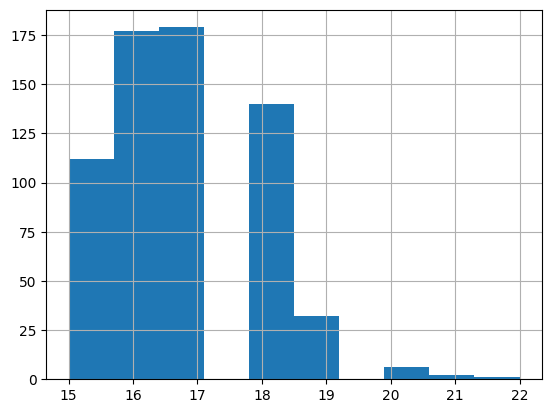

```python
# To see the disparity between the age distribution, we will check said distribution and its ratio as well
cleaned['age'].hist()
```

```python
# Eventually, we want to classify all available points. But for now, lets check the disparate impact for students who have passed the year
age_disp_impact = calc_disp_impact_ratio(df=cleaned, target_values=targ, target_col='G3', priv_col='age',
                                        target_thresh=11, priv_ident=17, sep_op='<=')

display(Markdown(f'**Disparate Impact Ratio:** ***{age_disp_impact} %***'))
```

```
Number of priviledged entities: 468
Number of unpriviledged entities: 181
Number of priviledged entities with favourable outcome: 342
Impact of priviledged group: 0.7307692307692307
Number of unpriviledged entities with favourable outcome: 110
Impact of unpriviledged group: 0.6077348066298343
```

**Disparate Impact Ratio:** **0.83 %**

As we can see, the disparity is not too bad, but there is still a bias.

```python
# First, we fefine the priviledged & unpriviledged groups, as well as instantiating the dataset
age_priv_group = [{'age': 1}]
age_unpriv_group = [{'age': 0}]

age_ds = StandardDataset(df=cleaned,
                    label_name='age',
                    protected_attribute_names=['age'],
                    favorable_classes=[1],
                    privileged_classes=[lambda x: 1 if x <= 17 else 0],
                    categorical_features=['school_GP', 'school_MS', 'address_R',
                                        'address_U', 'famsize_GT3', 'famsize_LE3', 'Pstatus_A', 'Pstatus_T',
                                        'Mjob_at_home', 'Mjob_health', 'Mjob_other', 'Mjob_services',
                                        'Mjob_teacher', 'Fjob_at_home', 'Fjob_health', 'Fjob_other',
                                        'Fjob_services', 'Fjob_teacher', 'reason_course', 'reason_home',
                                        'reason_other', 'reason_reputation', 'guardian_father',
                                        'guardian_mother', 'guardian_other'],
                    features_to_drop=['sex_F', 'sex_M']
                    )
```

Now, we will check the initial comparison metrics provided by aif360

A short summary of the metrics:

| Metric | Description | Reference |
| --- | --- | --- |
| `Disparate Impact Ratio` | Ratio of unprivileged group with favourable outcome to privileged group | Disparate Impact Ratio [3] |
| `Statistical Parity Difference` | In addition to the Disparate Impact, the Statistical Parity Difference calculates the actual difference in the proportion of favourable outcomes between the monitored and reference groups | Statistical Parity Difference [4] |
| `Smoothed Empirical Difference Fairness` | Calculates the difference in otucomes between different groups within features | Smoothed Empirical Difference Fairness [5] |

```python
initial_metrics = calc_bin_label_metrics(dataset=age_ds, priv_group=age_priv_group, unpriv_group=age_unpriv_group, display_results=True)
```

**Disparate Impact Ratio:** **0.0 %**

**Statistical Parity Difference:** **-1.0**

**Similarity of Data:** **69.0 %**

**Smoothed Empirical Difference Fairness:** **6.84**

What the results tell us:

- According to aif360, there is a maximum difference in favourable outcomes for younger and older students (Disparate Impact Ratio = 0%, as well as -1 in Statistical Parity).
- The data is quite similar for both groups
- The actual characteristics/group of characteristics are very different.

Interestingly, the manual calculation of the Disparate Impact Ratio does not agree with the manual calculation of the ratio showing our originally selected unprivileged group, despite the fact that they have exactly the same parameters. So there may be a problem with the dataset. However, no error was found. So we move on.

Finally, we want to check how the ml techinques perform without any data manipulation.

```python
# Determine training and testdata
init_ft_train, init_ft_test, init_targ_train, init_targ_test = train_test_split(cleaned, targ, test_size=0.2)

# Predict
init_pred = classify_data(train_data=init_ft_train, train_targets=init_targ_train, to_predict=init_ft_test, techniques='all')
```

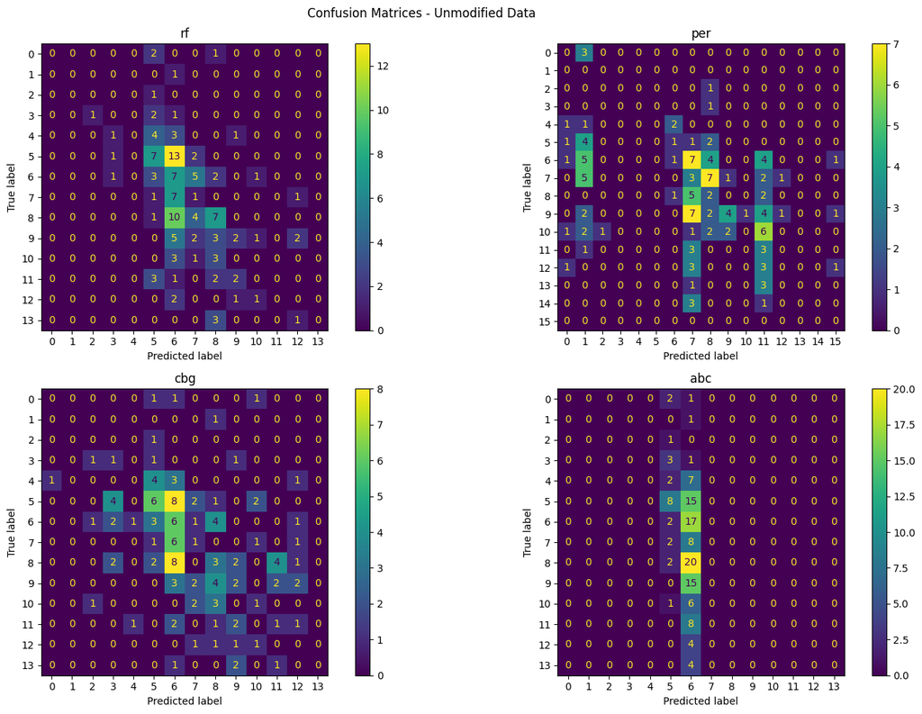

```python
# And check the confusion matrices
plot_conf_matrices(actual=init_targ_test, predicted=init_pred, suptitle='Confusion Matrices - Unmodified Data')
```

Note:

- rf = RandomForestClassifier [6]
- per = Perceptron [7]
- cbg = GradientBoostingClassifier [8]
- abc = AdaBoostClassifier [9]

From the first exploratory analysis, it seems that all models do not perform too well. However, both the random forest and the AdaBoost classifier do not normalise the predictions in any way. But let's also look at common performance metrics for ml modules.

```python
init_perf_metrics = calc_ml_perf_metrics(actual=init_targ_test, predictions=init_pred)
```

Results in %

|  | rf | per | cbg | abc |
| --- | --- | --- | --- | --- |
| precision | 36.32 | 32.73 | 19.73 | 76.17 |
| accuracy | 18.46 | 10.00 | 16.15 | 19.23 |
| f1-Score | 16.43 | 9.50 | 15.40 | 10.10 |
| recall | 18.46 | 10.00 | 16.15 | 19.23 |

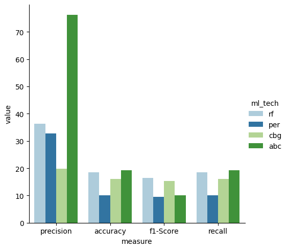

```python
# Let's also plot it for good measure
init_perf_metrics_df = pd.DataFrame.from_dict(init_perf_metrics).reset_index()
init_perf_metrics_df = init_perf_metrics_df.rename(columns={'index': 'measure'})
init_perf_metrics_df = init_perf_metrics_df.set_index('measure')
init_perf_metrics_df = init_perf_metrics_df.stack().to_frame('value').reset_index()
init_perf_metrics_df = init_perf_metrics_df.rename(columns={'level_1': 'ml_tech'})
init_per_plot = sns.catplot(data=init_perf_metrics_df, x='measure', y='value', hue='ml_tech', kind='bar', palette='Paired')
```

## Age - Preprocessing

The technique for preprocessing we are applying is Reweighing, which weighs and adapts different examples in each label combination [10].

```python
age_rew_inst = Reweighing(unprivileged_groups=age_unpriv_group, privileged_groups=age_priv_group)
age_rew_fit = age_rew_inst.fit(age_ds)
age_rew_res = age_rew_fit.transform(age_ds)
```

```python
display(HTML(age_rew_res.convert_to_dataframe()[0].head(10).to_html()))
```

|  | Medu | Fedu | traveltime | studytime | failures | schoolsup | famsup | paid | activities | nursery | higher | internet | romantic | famrel | freetime | goout | Dalc | Walc | health | absences | school_GP=False | school_GP=True | school_MS=False | school_MS=True | address_R=False | address_R=True | address_U=False | address_U=True | famsize_GT3=False | … |
| --- | --- | --- | --- | --- | --- | --- | --- | --- | --- | --- | --- | --- | --- | --- | --- | --- | --- | --- | --- | --- | --- | --- | --- | --- | --- | --- | --- | --- | --- | --- |
| 0 | 4.0 | 4.0 | 2.0 | 2.0 | 0.0 | 1.0 | 0.0 | 0.0 | 0.0 | 1.0 | 1.0 | 0.0 | 0.0 | 4.0 | 3.0 | 4.0 | 1.0 | 1.0 | 3.0 | 4.0 | 0.0 | 1.0 | 1.0 | 0.0 | 1.0 | 0.0 | 0.0 | 1.0 | 0.0 | … |
| 1 | 1.0 | 1.0 | 1.0 | 2.0 | 0.0 | 0.0 | 1.0 | 0.0 | 0.0 | 0.0 | 1.0 | 1.0 | 0.0 | 5.0 | 3.0 | 3.0 | 1.0 | 1.0 | 3.0 | 2.0 | 0.0 | 1.0 | 1.0 | 0.0 | 1.0 | 0.0 | 0.0 | 1.0 | 0.0 | … |
| 2 | 1.0 | 1.0 | 1.0 | 2.0 | 0.0 | 1.0 | 0.0 | 0.0 | 0.0 | 1.0 | 1.0 | 1.0 | 0.0 | 4.0 | 3.0 | 2.0 | 2.0 | 3.0 | 3.0 | 6.0 | 0.0 | 1.0 | 1.0 | 0.0 | 1.0 | 0.0 | 0.0 | 1.0 | 1.0 | … |
| 3 | 4.0 | 2.0 | 1.0 | 3.0 | 0.0 | 0.0 | 1.0 | 0.0 | 1.0 | 1.0 | 1.0 | 1.0 | 1.0 | 3.0 | 2.0 | 2.0 | 1.0 | 1.0 | 5.0 | 0.0 | 0.0 | 1.0 | 1.0 | 0.0 | 1.0 | 0.0 | 0.0 | 1.0 | 0.0 | … |
| 4 | 3.0 | 3.0 | 1.0 | 2.0 | 0.0 | 0.0 | 1.0 | 0.0 | 0.0 | 1.0 | 1.0 | 0.0 | 0.0 | 4.0 | 3.0 | 2.0 | 1.0 | 2.0 | 5.0 | 0.0 | 0.0 | 1.0 | 1.0 | 0.0 | 1.0 | 0.0 | 0.0 | 1.0 | 0.0 | … |
| 5 | 4.0 | 3.0 | 1.0 | 2.0 | 0.0 | 0.0 | 1.0 | 0.0 | 1.0 | 1.0 | 1.0 | 1.0 | 0.0 | 5.0 | 4.0 | 2.0 | 1.0 | 2.0 | 5.0 | 6.0 | 0.0 | 1.0 | 1.0 | 0.0 | 1.0 | 0.0 | 0.0 | 1.0 | 1.0 | … |
| 6 | 2.0 | 2.0 | 1.0 | 2.0 | 0.0 | 0.0 | 0.0 | 0.0 | 0.0 | 1.0 | 1.0 | 1.0 | 0.0 | 4.0 | 4.0 | 4.0 | 1.0 | 1.0 | 3.0 | 0.0 | 0.0 | 1.0 | 1.0 | 0.0 | 1.0 | 0.0 | 0.0 | 1.0 | 1.0 | … |
| 7 | 4.0 | 4.0 | 2.0 | 2.0 | 0.0 | 1.0 | 1.0 | 0.0 | 0.0 | 1.0 | 1.0 | 0.0 | 0.0 | 4.0 | 1.0 | 4.0 | 1.0 | 1.0 | 1.0 | 2.0 | 0.0 | 1.0 | 1.0 | 0.0 | 1.0 | 0.0 | 0.0 | 1.0 | 0.0 | … |
| 8 | 3.0 | 2.0 | 1.0 | 2.0 | 0.0 | 0.0 | 1.0 | 0.0 | 0.0 | 1.0 | 1.0 | 1.0 | 0.0 | 4.0 | 2.0 | 2.0 | 1.0 | 1.0 | 1.0 | 0.0 | 0.0 | 1.0 | 1.0 | 0.0 | 1.0 | 0.0 | 0.0 | 1.0 | 1.0 | … |
| 9 | 3.0 | 4.0 | 1.0 | 2.0 | 0.0 | 0.0 | 1.0 | 0.0 | 1.0 | 1.0 | 1.0 | 1.0 | 0.0 | 5.0 | 5.0 | 1.0 | 1.0 | 1.0 | 5.0 | 0.0 | 0.0 | 1.0 | 1.0 | 0.0 | 1.0 | 0.0 | 0.0 | 1.0 | 0.0 | … |

Apparently not too much has changed apart from converting each number to a float. At least it matches the bias metrics on the dataset from before. Let's see if the benchmarks have changed.

```python
# Determine training and testdata
age_rew_df = age_rew_res.convert_to_dataframe()[0]
age_rew_ft_train, age_rew_ft_test, age_rew_targ_train, age_rew_targ_test = train_test_split(age_rew_df, targ, test_size=0.2)

# Predict
age_rew_pred = classify_data(train_data=age_rew_ft_train, train_targets=age_rew_targ_train, to_predict=age_rew_ft_test, techniques='all')
```

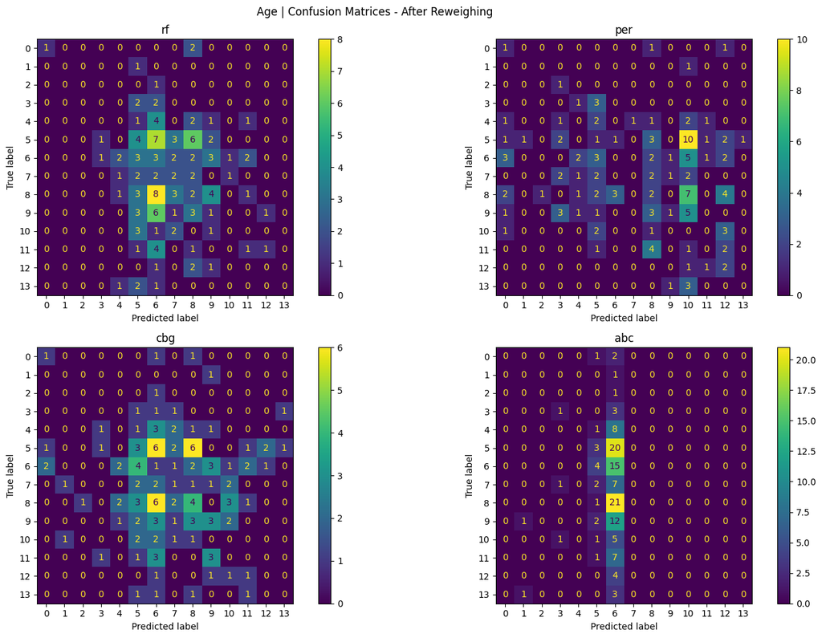

```python
# Confusion matrices
plot_conf_matrices(actual=init_targ_test, predicted=age_rew_pred, suptitle='Age | Confusion Matrices - After Reweighing')
```

```python
# Result without bias mitigation techniques
init_perf_metrics = calc_ml_perf_metrics(actual=init_targ_test, predictions=init_pred)
# Result after reweighing
age_rew_perf_metrics = calc_ml_perf_metrics(actual=age_rew_targ_test, predictions=age_rew_pred)
```

Results in %

|  | rf | per | cbg | abc |
| --- | --- | --- | --- | --- |
| precision | 36.32 | 32.73 | 19.73 | 76.17 |
| accuracy | 18.46 | 10.00 | 16.15 | 19.23 |
| f1-Score | 16.43 | 9.50 | 15.40 | 10.10 |
| recall | 18.46 | 10.00 | 16.15 | 19.23 |

Results in %

|  | rf | per | cbg | abc |
| --- | --- | --- | --- | --- |
| precision | 16.89 | 9.34 | 15.42 | 71.89 |
| accuracy | 13.85 | 10.00 | 13.85 | 16.15 |
| f1-Score | 12.67 | 8.02 | 13.16 | 7.14 |
| recall | 13.85 | 10.00 | 13.85 | 16.15 |

```
Renaming the index column to "measure"
```

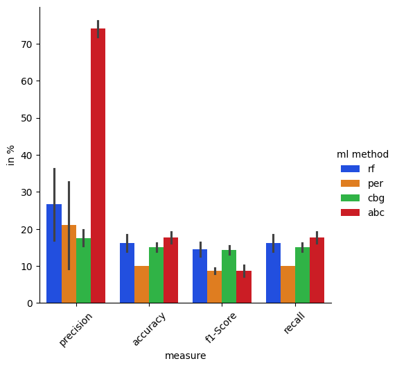

```python
# Plotted
init_perf_metrics_df = pd.DataFrame.from_dict(init_perf_metrics)
age_rew_perf_metrics_df = pd.DataFrame.from_dict(age_rew_perf_metrics)
age_rew_init_ml_perf_comp_df = pd.concat([init_perf_metrics_df, age_rew_perf_metrics_df], axis=0)
plot_grouped_barchart(data=age_rew_init_ml_perf_comp_df, index_col='measure', y_col='in %', stack_name='ml method')
```

```python
# Age - Original Result
display(Markdown('### Original Results'))
initial_bias_metrics = calc_bin_label_metrics(dataset=age_ds, priv_group=age_priv_group, unpriv_group=age_unpriv_group, display_results=True)
# Age - Results after reweighing
display(Markdown('### Results after Reweighing'))
age_rew_bias_metrics = calc_bin_label_metrics(dataset=age_rew_res, priv_group=age_priv_group, unpriv_group=age_unpriv_group, display_results=True)
```

Original Results

**Disparate Impact Ratio:** **0.0 %**

**Statistical Parity Difference:** **-1.0**

**Similarity of Data:** **69.0 %**

**Smoothed Empirical Difference Fairness:** **6.84**

Results after Reweighing

**Disparate Impact Ratio:** **0.0 %**

**Statistical Parity Difference:** **-1.0**

**Similarity of Data:** **69.0 %**

**Smoothed Empirical Difference Fairness:** **6.51**

```
             measure           data origin  value
0  disp_impact_ratio  without modification   0.00
1  disp_impact_ratio      after reweighing   0.00
2      stat_par_diff  without modification  -1.00
3      stat_par_diff      after reweighing  -1.00
4        consistency  without modification   0.69
5        consistency      after reweighing   0.69
6  smo_emp_diff_fair  without modification   6.84
7  smo_emp_diff_fair      after reweighing   6.51
```

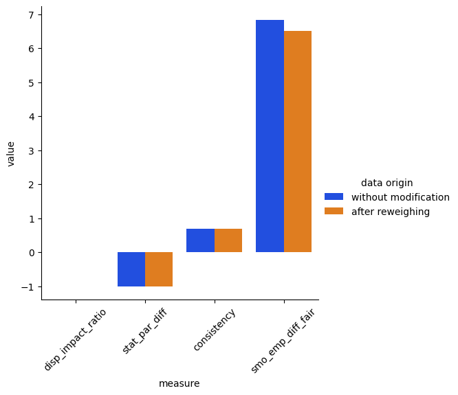

```python
# And the according visualization
# initial_bias_metrics_df = pd.DataFrame.from_dict(initial_bias_metrics)
rew_to_conv = {'without modification': initial_bias_metrics,
               'after reweighing': age_rew_bias_metrics}

age_rew_bias_comp_df = pd.DataFrame.from_dict(rew_to_conv).reset_index()
age_rew_bias_comp_df = age_rew_bias_comp_df.rename(columns={'index': 'measure'})
age_rew_bias_comp_df = age_rew_bias_comp_df.set_index('measure')
age_rew_bias_comp_df = age_rew_bias_comp_df.stack().to_frame('value').reset_index()
age_rew_bias_comp_df = age_rew_bias_comp_df.rename(columns={'level_1': 'data origin'})

print(age_rew_bias_comp_df)

init_per_plot = sns.catplot(data=age_rew_bias_comp_df, x='measure', y='value', hue='data origin', kind='bar', palette='bright')
init_per_plot.set_xticklabels(rotation=45)
plt.show()
```

In fact, not much has changed, apart from a slight decrease between the data distributions to compensate for empirical differences.

## Age - Inprocessing

As briefly introduced before, for inprocessing, we use the Adversarial Debiasing techinque. AAdversarial debiasing aims to train to accurately classify the target while simultaneously training a "discriminator" to predict the protected attribute based on the result of the training cycles. The objective is to reduce the performance of the discriminator so that it cannot predict the favourable or unfavourable group reliably anymore [11]. Contrary to preprocessing techniques, Adversarial Debiasing requires active training epochs to work. Thus, we follow the example provided by the developers of aif360 and create a Tensorflow session.

```python
# Inprocessing requires a bit more preparation. As it works during training, we already need train-test splits beforehand.
age_ds_train, age_ds_test = age_ds.split(num_or_size_splits=[0.2], shuffle=False) # Data shuffling is switched off for reproducibility

# Start the tensorflow sesssion
tf.reset_default_graph()
sess = tf.Session()

age_adv_deb = AdversarialDebiasing(privileged_groups=age_priv_group,
                    unprivileged_groups=age_unpriv_group,
                    scope_name='age_adv_classifier',
                    debias=True,
                    sess=sess)

age_adv_deb_fitted = age_adv_deb.fit(age_ds_train) # Note: we use the unmodified dataset again
age_adv_deb_predicted = age_adv_deb_fitted.predict(age_ds_test)

# And close the session
sess.close()
```

```
epoch 0; iter: 0; batch classifier loss: 0.358656; batch adversarial loss: 1.267355
epoch 1; iter: 0; batch classifier loss: 0.252909; batch adversarial loss: 1.329363
epoch 2; iter: 0; batch classifier loss: 0.173077; batch adversarial loss: 1.365194
epoch 3; iter: 0; batch classifier loss: 0.124004; batch adversarial loss: 1.381511
epoch 4; iter: 0; batch classifier loss: 0.100119; batch adversarial loss: 1.388388
epoch 5; iter: 0; batch classifier loss: 0.089747; batch adversarial loss: 1.387328
epoch 6; iter: 0; batch classifier loss: 0.089889; batch adversarial loss: 1.386014
epoch 7; iter: 0; batch classifier loss: 0.079459; batch adversarial loss: 1.384986
epoch 8; iter: 0; batch classifier loss: 0.073367; batch adversarial loss: 1.383354
epoch 9; iter: 0; batch classifier loss: 0.062862; batch adversarial loss: 1.380771
epoch 10; iter: 0; batch classifier loss: 0.051938; batch adversarial loss: 1.379856
epoch 11; iter: 0; batch classifier loss: 0.056656; batch adversarial loss: 1.377373
epoch 12; iter: 0; batch classifier loss: 0.051203; batch adversarial loss: 1.375293
epoch 13; iter: 0; batch classifier loss: 0.044289; batch adversarial loss: 1.373639
epoch 14; iter: 0; batch classifier loss: 0.047509; batch adversarial loss: 1.371443
epoch 15; iter: 0; batch classifier loss: 0.041377; batch adversarial loss: 1.369246
epoch 16; iter: 0; batch classifier loss: 0.036911; batch adversarial loss: 1.367236
epoch 17; iter: 0; batch classifier loss: 0.036237; batch adversarial loss: 1.365330
epoch 18; iter: 0; batch classifier loss: 0.037775; batch adversarial loss: 1.362407
epoch 19; iter: 0; batch classifier loss: 0.043480; batch adversarial loss: 1.361253
epoch 20; iter: 0; batch classifier loss: 0.034272; batch adversarial loss: 1.358806
epoch 21; iter: 0; batch classifier loss: 0.036719; batch adversarial loss: 1.355939
epoch 22; iter: 0; batch classifier loss: 0.029913; batch adversarial loss: 1.353856
epoch 23; iter: 0; batch classifier loss: 0.019959; batch adversarial loss: 1.353069
epoch 24; iter: 0; batch classifier loss: 0.025785; batch adversarial loss: 1.349798
epoch 25; iter: 0; batch classifier loss: 0.022606; batch adversarial loss: 1.348275
epoch 26; iter: 0; batch classifier loss: 0.027240; batch adversarial loss: 1.346067
epoch 27; iter: 0; batch classifier loss: 0.028380; batch adversarial loss: 1.343103
epoch 28; iter: 0; batch classifier loss: 0.022197; batch adversarial loss: 1.341496
epoch 29; iter: 0; batch classifier loss: 0.022949; batch adversarial loss: 1.338922
epoch 30; iter: 0; batch classifier loss: 0.014609; batch adversarial loss: 1.338592
epoch 31; iter: 0; batch classifier loss: 0.018310; batch adversarial loss: 1.335396
epoch 32; iter: 0; batch classifier loss: 0.022244; batch adversarial loss: 1.332387
epoch 33; iter: 0; batch classifier loss: 0.011698; batch adversarial loss: 1.332048
epoch 34; iter: 0; batch classifier loss: 0.026461; batch adversarial loss: 1.327801
epoch 35; iter: 0; batch classifier loss: 0.017176; batch adversarial loss: 1.326576
epoch 36; iter: 0; batch classifier loss: 0.009569; batch adversarial loss: 1.330356
epoch 37; iter: 0; batch classifier loss: 0.012112; batch adversarial loss: 1.322892
epoch 38; iter: 0; batch classifier loss: 0.010638; batch adversarial loss: 1.321055
epoch 39; iter: 0; batch classifier loss: 0.009970; batch adversarial loss: 1.318878
epoch 40; iter: 0; batch classifier loss: 0.016022; batch adversarial loss: 1.315526
epoch 41; iter: 0; batch classifier loss: 0.016805; batch adversarial loss: 1.313499
epoch 42; iter: 0; batch classifier loss: 0.012982; batch adversarial loss: 1.311755
epoch 43; iter: 0; batch classifier loss: 0.016996; batch adversarial loss: 1.308858
epoch 44; iter: 0; batch classifier loss: 0.017764; batch adversarial loss: 1.306587
epoch 45; iter: 0; batch classifier loss: 0.017992; batch adversarial loss: 1.304434
epoch 46; iter: 0; batch classifier loss: 0.016554; batch adversarial loss: 1.302429
epoch 47; iter: 0; batch classifier loss: 0.021087; batch adversarial loss: 1.299828
epoch 48; iter: 0; batch classifier loss: 0.021156; batch adversarial loss: 1.298217
epoch 49; iter: 0; batch classifier loss: 0.024216; batch adversarial loss: 1.295431
```

```python
# Result after Adversarial Debiasing
# Note: We use the train-targets from the train-test split here again, as the sample size (mostly - difference of 1 row)
# matches and the data is unmodified
age_adv_deb_preds_df = age_adv_deb_predicted.convert_to_dataframe()[0][: 519]

age_adv_deb_pred = classify_data(train_data=age_adv_deb_preds_df, train_targets=age_rew_targ_train, to_predict=age_rew_ft_test, techniques='all')
```

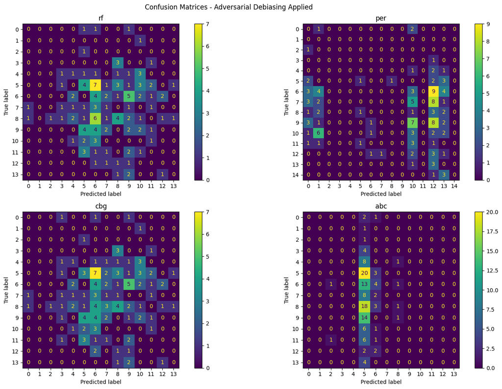

```python
# Confusion matrices after Adversarial Debiasing
plot_conf_matrices(actual=init_targ_test, predicted=age_adv_deb_pred, suptitle='Confusion Matrices - Adversarial Debiasing Applied')
```

The results appear to be worse than the reweighing. But we will also see how the metrics look in real numbers.

```python
# Result without bias mitigation techniques
init_perf_metrics = calc_ml_perf_metrics(actual=init_targ_test, predictions=init_pred)
# Result after Adversarial Debiasing
age_adv_deb_perf_metrics = calc_ml_perf_metrics(actual=age_rew_targ_test, predictions=age_adv_deb_pred)
```

Results in %

|  | rf | per | cbg | abc |
| --- | --- | --- | --- | --- |
| precision | 36.32 | 32.73 | 19.73 | 76.17 |
| accuracy | 18.46 | 10.00 | 16.15 | 19.23 |
| f1-Score | 16.43 | 9.50 | 15.40 | 10.10 |
| recall | 18.46 | 10.00 | 16.15 | 19.23 |

Results in %

|  | rf | per | cbg | abc |
| --- | --- | --- | --- | --- |
| precision | 13.20 | 32.99 | 15.08 | 58.31 |
| accuracy | 11.54 | 6.92 | 13.08 | 13.08 |
| f1-Score | 10.83 | 3.20 | 12.63 | 4.36 |
| recall | 11.54 | 6.92 | 13.08 | 13.08 |

```
Renaming the index column to "measure"
```

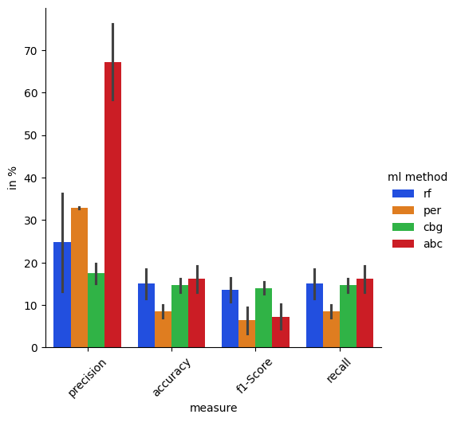

```python
# And the barchart
age_adv_deb_perf_metrics_df = pd.DataFrame.from_dict(age_adv_deb_perf_metrics)
age_adv_deb_init_ml_perf_comp_df = pd.concat([age_adv_deb_perf_metrics_df, init_perf_metrics_df], axis=0)
plot_grouped_barchart(data=age_adv_deb_init_ml_perf_comp_df, index_col='measure', y_col='in %', stack_name='ml method')
```

Again, there is a slight decrease in the overall performance of the machine learning modules. The results are slightly worse compared to reweighing. Next, we examine the effect on the bias metrics.

```python
# Original Result
display(Markdown('### Original Results'))
initial_bias_metrics = calc_bin_label_metrics(dataset=age_ds, priv_group=age_priv_group, unpriv_group=age_unpriv_group, display_results=True)
# Results after adversarial debiasing
display(Markdown('### Results after Adversarial Debiasing'))
age_adv_deb_bias_metrics = calc_bin_label_metrics(dataset=age_adv_deb_predicted, priv_group=age_priv_group,
                                                  unpriv_group=age_unpriv_group, display_results=True)
```

Original Results

**Disparate Impact Ratio:** **0.0 %**

**Statistical Parity Difference:** **-1.0**

**Similarity of Data:** **69.0 %**

**Smoothed Empirical Difference Fairness:** **6.84**

Results after Adversarial Debiasing

**Disparate Impact Ratio:** **100.0 %**

**Statistical Parity Difference:** **0.0**

**Similarity of Data:** **100.0 %**

**Smoothed Empirical Difference Fairness:** **0.64**

```
             measure                   data origin  value
0  disp_impact_ratio          without modification   0.00
1  disp_impact_ratio  after adversiarial debiasing   1.00
2      stat_par_diff          without modification  -1.00
3      stat_par_diff  after adversiarial debiasing   0.00
4        consistency          without modification   0.69
5        consistency  after adversiarial debiasing   1.00
6  smo_emp_diff_fair          without modification   6.84
7  smo_emp_diff_fair  after adversiarial debiasing   0.64
```

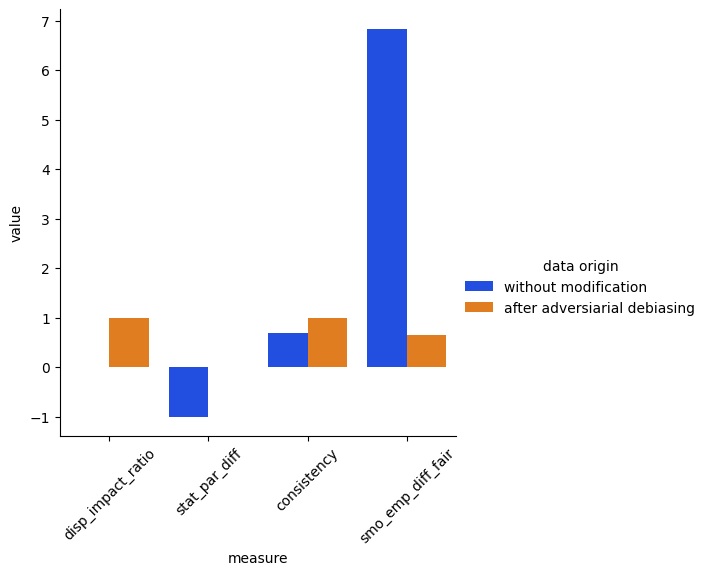

```python
# + plot
age_adv_deb_to_conv = {'without modification': initial_bias_metrics,
               'after adversiarial debiasing': age_adv_deb_bias_metrics}

age_adv_deb_bias_comp_df = pd.DataFrame.from_dict(age_adv_deb_to_conv).reset_index()
age_adv_deb_bias_comp_df = age_adv_deb_bias_comp_df.rename(columns={'index': 'measure'})
age_adv_deb_bias_comp_df = age_adv_deb_bias_comp_df.set_index('measure')
age_adv_deb_bias_comp_df = age_adv_deb_bias_comp_df.stack().to_frame('value').reset_index()
age_adv_deb_bias_comp_df = age_adv_deb_bias_comp_df.rename(columns={'level_1': 'data origin'})

print(age_adv_deb_bias_comp_df)

init_per_plot = sns.catplot(data=age_adv_deb_bias_comp_df, x='measure', y='value', hue='data origin', kind='bar', palette='bright')
init_per_plot.set_xticklabels(rotation=45)
plt.show()
```

## Age - Postprocessing

Finally, the last set of mitigation techniques is applied after training to the prediction results via Calibrated Equalised Odds. This technique aims to opimize the classifier score by adapting the prediction output [12]. Unlike the first two sets of mitigation techniques, a dataset containing processed data is required in addition to the base dataset. Therefore, we will use the result of the adversarial debiasing technique. As the name suggests, pos-processing usually implies that the training is done and is only applied to predictions. Therefore, we will only look at the final bias metrics.

```python
age_post_inst = CalibratedEqOddsPostprocessing(unprivileged_groups=age_unpriv_group,
                                                privileged_groups=age_priv_group)

age_post_predicted = age_post_inst.fit_predict(dataset_pred=age_adv_deb_predicted, dataset_true=age_ds_test)
```

```python
# Original Result
display(Markdown('### Original Results'))
initial_bias_metrics = calc_bin_label_metrics(dataset=age_ds, priv_group=age_priv_group, unpriv_group=age_unpriv_group, display_results=True)
# Results after postprocessing
display(Markdown('### Results after calibrated equalized odds'))
age_post_bias_metrics = calc_bin_label_metrics(dataset=age_post_predicted, priv_group=age_priv_group,
                                               unpriv_group=age_unpriv_group, display_results=True)
```

Original Results

**Disparate Impact Ratio:** **0.0 %**

**Statistical Parity Difference:** **-1.0**

**Similarity of Data:** **69.0 %**

**Smoothed Empirical Difference Fairness:** **6.84**

Results after calibrated equalized odds

**Disparate Impact Ratio:** **100.0 %**

**Statistical Parity Difference:** **0.0**

**Similarity of Data:** **100.0 %**

**Smoothed Empirical Difference Fairness:** **0.64**

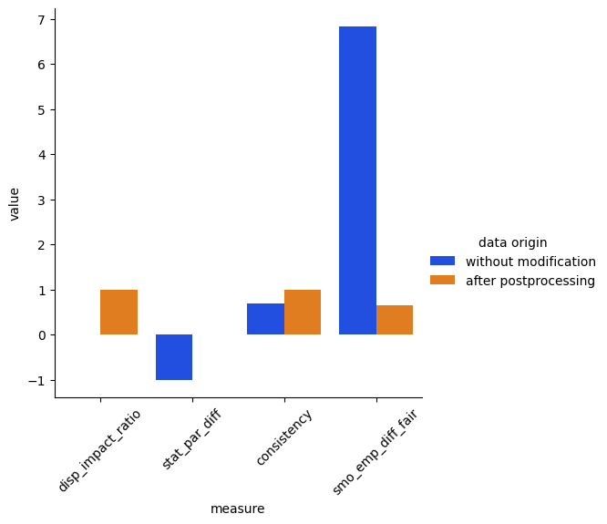

```python
# + plot
age_post_to_conv = {'without modification': initial_bias_metrics,
               'after postprocessing': age_post_bias_metrics}

age_post_comp_df = pd.DataFrame.from_dict(age_post_to_conv).reset_index()
age_post_comp_df = age_post_comp_df.rename(columns={'index': 'measure'})
age_post_comp_df = age_post_comp_df.set_index('measure')
age_post_comp_df = age_post_comp_df.stack().to_frame('value').reset_index()
age_post_comp_df = age_post_comp_df.rename(columns={'level_1': 'data origin'})

init_per_plot = sns.catplot(data=age_post_comp_df, x='measure', y='value', hue='data origin', kind='bar', palette='bright')
init_per_plot.set_xticklabels(rotation=45)
plt.show()
```

As observable, postprocessing made no difference after application in this case.

## Summary - Student with age as protected attribute

In the following heatmap each of the results can be observed. Please note, that for the ml performance metrics, only the results from the Random Forests are displayed, as this is the ml technique used for the `Fairlearn` section as well.

```python
fin_age_init_perf_met = init_perf_metrics_df['rf']
fin_age_init_perf_met['stage'] = 'without modification'
fin_age_rew_metr = age_rew_perf_metrics_df['rf']
fin_age_rew_metr['stage'] = 'after reweighing'
fin_age_adv_deb_metr = age_adv_deb_perf_metrics_df['rf']
fin_age_adv_deb_metr['stage'] = 'after adversarial debiasing'
age_fin_ml_per_df = pd.DataFrame([fin_age_init_perf_met, fin_age_rew_metr, fin_age_adv_deb_metr]).reset_index()
age_fin_ml_per_df = age_fin_ml_per_df.drop(columns='index').set_index('stage')
age_fin_ml_per_df
```

| stage | precision | accuracy | f1-Score | recall |
| --- | --- | --- | --- | --- |
| without modification | 36.32 | 18.46 | 16.43 | 18.46 |
| after reweighing | 16.89 | 13.85 | 12.67 | 13.85 |
| after adversarial debiasing | 13.20 | 11.54 | 10.83 | 11.54 |

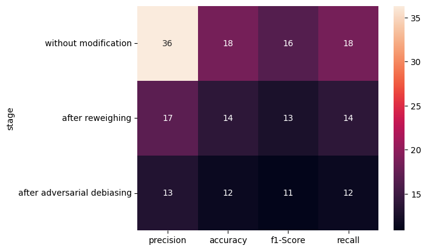

```python
age_fin_ml_plot= sns.heatmap(data=age_fin_ml_per_df, annot=True)
plt.show()
```

And the result of the bias mitigation techniques:

```python
age_fin_bias_metrics = {'without modification': initial_bias_metrics,
                        'after reweighing': age_rew_bias_metrics,
                        'after adversarial debiasing': age_adv_deb_bias_metrics,
                        'after  calculating equalized odds': age_post_bias_metrics
                    }

age_fin_bias_metrics_df = pd.DataFrame.from_dict(age_fin_bias_metrics)
age_fin_bias_metrics_df
```

|  | without modification | after reweighing | after adversarial debiasing | after calculating equalized odds |
| --- | --- | --- | --- | --- |
| disp_impact_ratio | 0.00 | 0.00 | 1.00 | 1.00 |
| stat_par_diff | -1.00 | -1.00 | 0.00 | 0.00 |
| consistency | 0.69 | 0.69 | 1.00 | 1.00 |
| smo_emp_diff_fair | 6.84 | 6.51 | 0.64 | 0.64 |

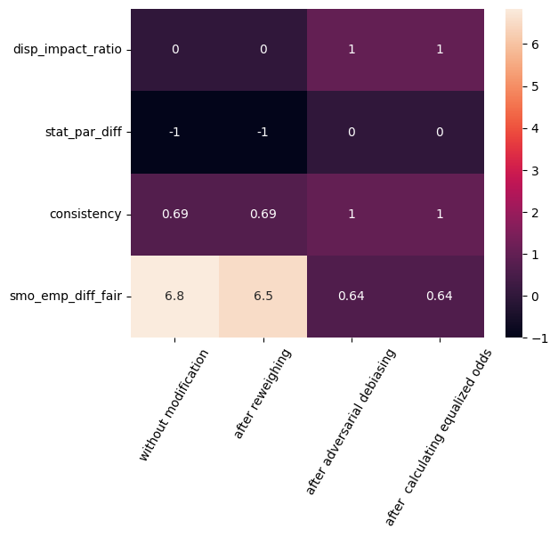

```python
age_fin_bias_plot = sns.heatmap(data=age_fin_bias_metrics_df, annot=True)
age_fin_bias_plot.set_xticklabels(labels=age_fin_bias_metrics_df[: 0], rotation=60)
plt.show()
```

## Student Dataset - Workday Alcohol Consumption (Dalc)

As a next step, we want to check whether different results are obtained when using a different protected characteristic. For this check we use the hypothesis that higher alcohol consumption during/after a working day has a negative effect on school performance. To do this, we first check the possible values of Dalc and the distribution.

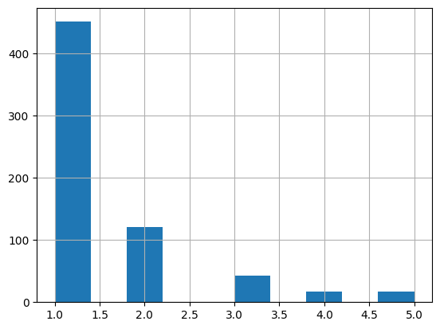

```python
# Check all possible values of Dalc
cleaned['Dalc'].unique()
cleaned['Dalc'].hist()
plt.show()
```

It can be assumed that the majority drink up to ~1.5 drinks per working day. Therefore, it can be assumed that students who drink more than this will be considered unhealthy. For the upcoming comparisons, the threshold will be more than two drinks, where those who drink less will be considered favourable and those who drink more will be considered unfavourable.

```python
# Define the favourable & unvafourable group
dalc_priv_group = [{'Dalc': 1}]
dalc_unpriv_group = [{'Dalc': 0}]
```

```python
# Instantiate the dataset with dalc as protected attribute.
# # Furthermore, we drop the age to see distinct results compared to the first section
dalc_ds = StandardDataset(df=cleaned,
                    label_name='Dalc',
                    protected_attribute_names=['Dalc'],
                    favorable_classes=[1],
                    privileged_classes=[lambda x: 1 if x <= 2.0 else 0],
                    categorical_features=['school_GP', 'school_MS', 'sex_F', 'sex_M', 'address_R',
                                        'address_U', 'famsize_GT3', 'famsize_LE3', 'Pstatus_A', 'Pstatus_T',
                                        'Mjob_at_home', 'Mjob_health', 'Mjob_other', 'Mjob_services',
                                        'Mjob_teacher', 'Fjob_at_home', 'Fjob_health', 'Fjob_other',
                                        'Fjob_services', 'Fjob_teacher', 'reason_course', 'reason_home',
                                        'reason_other', 'reason_reputation', 'guardian_father',
                                        'guardian_mother', 'guardian_other']
                    )
```

Similarly to the age, we check the initial bias metrics first.

```python
# Bias metrics Dalc wihtout modifications
dalc_initial_metrics = calc_bin_label_metrics(dataset=dalc_ds, priv_group=dalc_priv_group, unpriv_group=dalc_unpriv_group, display_results=True)
```

**Disparate Impact Ratio:** **0.0 %**

**Statistical Parity Difference:** **-1.0**

**Similarity of Data:** **89.0 %**

**Smoothed Empirical Difference Fairness:** **7.04**

Again, we see a fairly similar picture compared to age. However, it is interesting to see that the data is even more similar between the two groups created, as well as the difference between the group of other characteristics in the data is even more divergent overall.

```python
# For reference, we also check the manually calculated result again
dalc_disp_impact = calc_disp_impact_ratio(df=cleaned, target_values=targ, target_col='G3', priv_col='Dalc',
                                        target_thresh=11, priv_ident=2, sep_op='<=')

display(Markdown(f'**Disparate Impact Ratio:** ***{age_disp_impact} %***'))
```

```
Number of priviledged entities: 572
Number of unpriviledged entities: 77
Number of priviledged entities with favourable outcome: 411
Impact of priviledged group: 0.7185314685314685
Number of unpriviledged entities with favourable outcome: 41
Impact of unpriviledged group: 0.5324675324675324
```

**Disparate Impact Ratio:** **0.83 %**

Again, as with age, the manually calculated result differs from the method provided directly by aif360, indicating that something is not working properly when instantiating the dataset.

## Dalc - Preprocessing

```python
dalc_rew_inst = Reweighing(unprivileged_groups=dalc_unpriv_group, privileged_groups=dalc_priv_group)
dalc_rew_fit = dalc_rew_inst.fit(dalc_ds)
dalc_rew_res = dalc_rew_fit.transform(dalc_ds)
```

```python
display(HTML(dalc_rew_res .convert_to_dataframe()[0].head(10).to_html()))
```

|  | age | Medu | Fedu | traveltime | studytime | failures | schoolsup | famsup | paid | activities | nursery | higher | internet | romantic | famrel | freetime | goout | Walc | health | absences | school_GP=False | school_GP=True | school_MS=False | school_MS=True | sex_F=False | sex_F=True | sex_M=False | sex_M=True | address_R=False | … |
| --- | --- | --- | --- | --- | --- | --- | --- | --- | --- | --- | --- | --- | --- | --- | --- | --- | --- | --- | --- | --- | --- | --- | --- | --- | --- | --- | --- | --- | --- | --- |
| 0 | 18.0 | 4.0 | 4.0 | 2.0 | 2.0 | 0.0 | 1.0 | 0.0 | 0.0 | 0.0 | 1.0 | 1.0 | 0.0 | 0.0 | 4.0 | 3.0 | 4.0 | 1.0 | 3.0 | 4.0 | 0.0 | 1.0 | 1.0 | 0.0 | 0.0 | 1.0 | 1.0 | 0.0 | 1.0 | … |
| 1 | 17.0 | 1.0 | 1.0 | 1.0 | 2.0 | 0.0 | 0.0 | 1.0 | 0.0 | 0.0 | 0.0 | 1.0 | 1.0 | 0.0 | 5.0 | 3.0 | 3.0 | 1.0 | 3.0 | 2.0 | 0.0 | 1.0 | 1.0 | 0.0 | 0.0 | 1.0 | 1.0 | 0.0 | 1.0 | … |
| 2 | 15.0 | 1.0 | 1.0 | 1.0 | 2.0 | 0.0 | 1.0 | 0.0 | 0.0 | 0.0 | 1.0 | 1.0 | 1.0 | 0.0 | 4.0 | 3.0 | 2.0 | 3.0 | 3.0 | 6.0 | 0.0 | 1.0 | 1.0 | 0.0 | 0.0 | 1.0 | 1.0 | 0.0 | 1.0 | … |
| 3 | 15.0 | 4.0 | 2.0 | 1.0 | 3.0 | 0.0 | 0.0 | 1.0 | 0.0 | 1.0 | 1.0 | 1.0 | 1.0 | 1.0 | 3.0 | 2.0 | 2.0 | 1.0 | 5.0 | 0.0 | 0.0 | 1.0 | 1.0 | 0.0 | 0.0 | 1.0 | 1.0 | 0.0 | 1.0 | … |
| 4 | 16.0 | 3.0 | 3.0 | 1.0 | 2.0 | 0.0 | 0.0 | 1.0 | 0.0 | 0.0 | 1.0 | 1.0 | 0.0 | 0.0 | 4.0 | 3.0 | 2.0 | 2.0 | 5.0 | 0.0 | 0.0 | 1.0 | 1.0 | 0.0 | 0.0 | 1.0 | 1.0 | 0.0 | 1.0 | … |
| 5 | 16.0 | 4.0 | 3.0 | 1.0 | 2.0 | 0.0 | 0.0 | 1.0 | 0.0 | 1.0 | 1.0 | 1.0 | 1.0 | 0.0 | 5.0 | 4.0 | 2.0 | 2.0 | 5.0 | 6.0 | 0.0 | 1.0 | 1.0 | 0.0 | 1.0 | 0.0 | 0.0 | 1.0 | 1.0 | … |
| 6 | 16.0 | 2.0 | 2.0 | 1.0 | 2.0 | 0.0 | 0.0 | 0.0 | 0.0 | 0.0 | 1.0 | 1.0 | 1.0 | 0.0 | 4.0 | 4.0 | 4.0 | 1.0 | 3.0 | 0.0 | 0.0 | 1.0 | 1.0 | 0.0 | 1.0 | 0.0 | 0.0 | 1.0 | 1.0 | … |
| 7 | 17.0 | 4.0 | 4.0 | 2.0 | 2.0 | 0.0 | 1.0 | 1.0 | 0.0 | 0.0 | 1.0 | 1.0 | 0.0 | 0.0 | 4.0 | 1.0 | 4.0 | 1.0 | 1.0 | 2.0 | 0.0 | 1.0 | 1.0 | 0.0 | 0.0 | 1.0 | 1.0 | 0.0 | 1.0 | … |
| 8 | 15.0 | 3.0 | 2.0 | 1.0 | 2.0 | 0.0 | 0.0 | 1.0 | 0.0 | 0.0 | 1.0 | 1.0 | 1.0 | 0.0 | 4.0 | 2.0 | 2.0 | 1.0 | 1.0 | 0.0 | 0.0 | 1.0 | 1.0 | 0.0 | 1.0 | 0.0 | 0.0 | 1.0 | 1.0 | … |
| 9 | 15.0 | 3.0 | 4.0 | 1.0 | 2.0 | 0.0 | 0.0 | 1.0 | 0.0 | 1.0 | 1.0 | 1.0 | 1.0 | 0.0 | 5.0 | 5.0 | 1.0 | 1.0 | 5.0 | 0.0 | 0.0 | 1.0 | 1.0 | 0.0 | 1.0 | 0.0 | 0.0 | 1.0 | 1.0 | … |

```python
# Determine training- and test-data
dalc_rew_df = dalc_rew_res.convert_to_dataframe()[0]
dalc_rew_ft_train, dalc_rew_ft_test, dalc_rew_targ_train, dalc_rew_targ_test = train_test_split(dalc_rew_df, targ, test_size=0.2)

# Predict
dalc_rew_pred = classify_data(train_data=dalc_rew_ft_train, train_targets=dalc_rew_targ_train, to_predict=dalc_rew_ft_test, techniques='all')
```

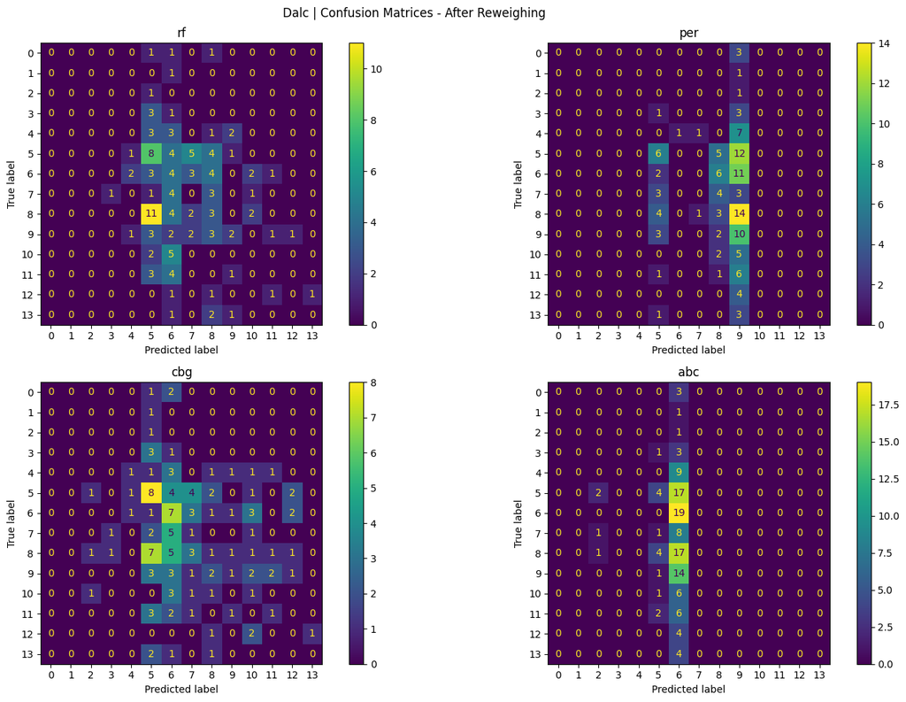

```python
# Confusion matrices
plot_conf_matrices(actual=init_targ_test, predicted=dalc_rew_pred, suptitle='Dalc | Confusion Matrices - After Reweighing')
```

```python
# Result without bias mitigation techniques
init_perf_metrics = calc_ml_perf_metrics(actual=init_targ_test, predictions=init_pred)
# Result after reweighing
dalc_rew_perf_metrics = calc_ml_perf_metrics(actual=dalc_rew_targ_test, predictions=dalc_rew_pred)
```

Results in %

|  | rf | per | cbg | abc |
| --- | --- | --- | --- | --- |
| precision | 36.32 | 32.73 | 19.73 | 76.17 |
| accuracy | 18.46 | 10.00 | 16.15 | 19.23 |
| f1-Score | 16.43 | 9.50 | 15.40 | 10.10 |
| recall | 18.46 | 10.00 | 16.15 | 19.23 |

Results in %

|  | rf | per | cbg | abc |
| --- | --- | --- | --- | --- |
| precision | 28.97 | 48.54 | 25.26 | 76.74 |
| accuracy | 14.62 | 19.23 | 18.46 | 14.62 |
| f1-Score | 12.64 | 9.88 | 17.20 | 5.04 |
| recall | 14.62 | 19.23 | 18.46 | 14.62 |

```
Renaming the index column to "measure"
```

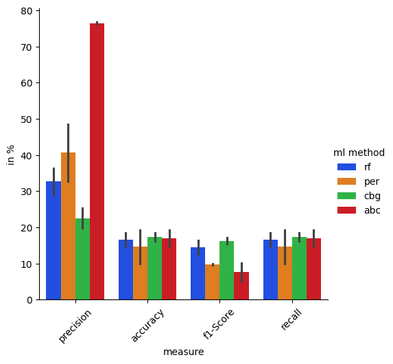

```python
init_perf_metrics_df = pd.DataFrame.from_dict(init_perf_metrics)
dalc_rew_perf_metrics_df = pd.DataFrame.from_dict(dalc_rew_perf_metrics)
dalc_rew_init_ml_perf_comp_df = pd.concat([init_perf_metrics_df, dalc_rew_perf_metrics_df], axis=0)
plot_grouped_barchart(data=dalc_rew_init_ml_perf_comp_df, index_col='measure', y_col='in %', stack_name='ml method')
```

```python
# Original Result
display(Markdown('### Dalc - Original Results'))
dalc_initial_bias_metrics = calc_bin_label_metrics(dataset=dalc_ds, priv_group=dalc_priv_group,
                                            unpriv_group=dalc_unpriv_group, display_results=True)
# Results after reweighing
display(Markdown('### Dalc - Results after Reweighing'))
dalc_rew_bias_metrics = calc_bin_label_metrics(dataset=dalc_rew_res, priv_group=dalc_priv_group,
                                            unpriv_group=dalc_unpriv_group, display_results=True)
```

Dalc - Original Results

**Disparate Impact Ratio:** **0.0 %**

**Statistical Parity Difference:** **-1.0**

**Similarity of Data:** **89.0 %**

**Smoothed Empirical Difference Fairness:** **7.04**

Dalc - Results after Reweighing

**Disparate Impact Ratio:** **0.0 %**

**Statistical Parity Difference:** **-1.0**

**Similarity of Data:** **89.0 %**

**Smoothed Empirical Difference Fairness:** **6.87**

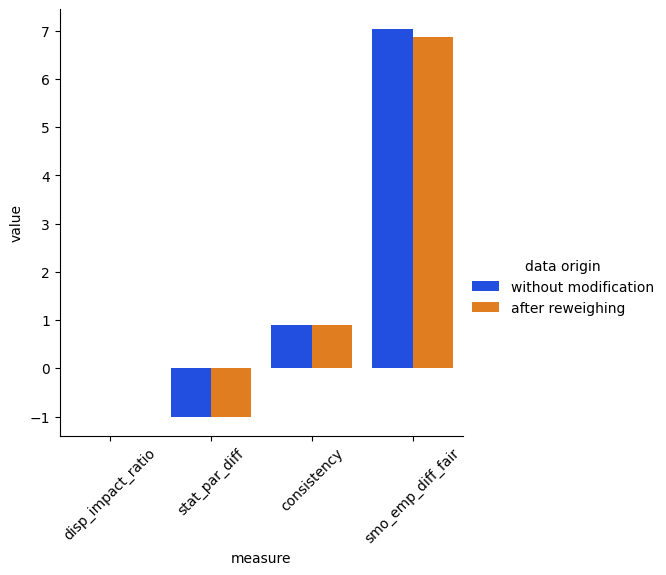

```python
# And the according visualization
dalc_rew_to_conv = {'without modification': dalc_initial_bias_metrics,
               'after reweighing': dalc_rew_bias_metrics}

dalc_rew_bias_comp_df = pd.DataFrame.from_dict(dalc_rew_to_conv).reset_index()
dalc_rew_bias_comp_df = dalc_rew_bias_comp_df.rename(columns={'index': 'measure'})
dalc_rew_bias_comp_df = dalc_rew_bias_comp_df.set_index('measure')
dalc_rew_bias_comp_df = dalc_rew_bias_comp_df.stack().to_frame('value').reset_index()
dalc_rew_bias_comp_df = dalc_rew_bias_comp_df.rename(columns={'level_1': 'data origin'})

init_per_plot = sns.catplot(data=dalc_rew_bias_comp_df, x='measure', y='value', hue='data origin', kind='bar', palette='bright')
init_per_plot.set_xticklabels(rotation=45)
plt.show()
```

The results of the bias metrics are also quite consistent. The empirical difference has been reduced slightly, while all other results remain more or less consistent with the unmodified data.

## Dalc - Inprocessing

```python
dalc_ds_train, dalc_ds_test = dalc_ds.split(num_or_size_splits=[0.2], shuffle=False) # Data shuffling is turned of for reproducability purposes

# Start the tensorflow sesssion
tf.reset_default_graph()
sess = tf.Session()

dalc_adv_deb = AdversarialDebiasing(privileged_groups =dalc_priv_group,
                    unprivileged_groups=dalc_unpriv_group,
                    scope_name='dalc_adv_classifier',
                    debias=True,
                    sess=sess)

dalc_adv_deb_fitted = dalc_adv_deb.fit(dalc_ds_train) # Note: we use the unmodified dataset again
dalc_adv_deb_predicted = dalc_adv_deb_fitted.predict(dalc_ds_test)

sess.close()
```

[output not shown]

```python
# Note: We use the train-targets from the train-test split here again, as the sample size (mostly - difference of 1 row)
# matches and the data is unmodified
dalc_adv_deb_preds_df = dalc_adv_deb_predicted.convert_to_dataframe()[0][: 519]

dalc_adv_deb_pred = classify_data(train_data=dalc_adv_deb_preds_df, train_targets=dalc_rew_targ_train,
                                to_predict=dalc_rew_ft_test, techniques='all')
```

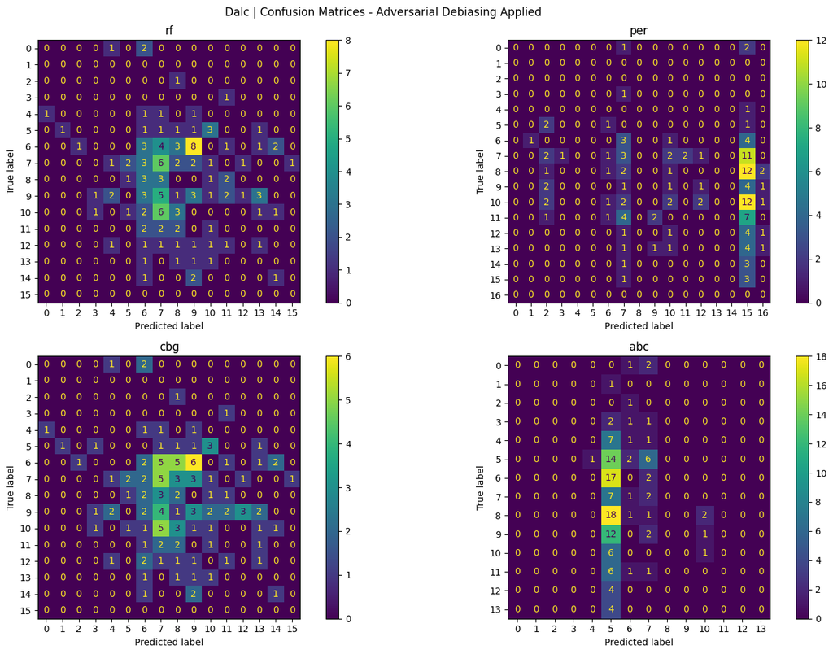

```python
# Confusion matrices for Dalc after Adversarial Debiasing
plot_conf_matrices(actual=init_targ_test, predicted=dalc_adv_deb_pred, suptitle='Dalc | Confusion Matrices - Adversarial Debiasing Applied')
```

```python
# Result without bias mitigation techniques
init_perf_metrics = calc_ml_perf_metrics(actual=init_targ_test, predictions=init_pred)
# Result after Adversarial Debiasing
dalc_adv_deb_perf_metrics = calc_ml_perf_metrics(actual=dalc_rew_targ_test, predictions=dalc_adv_deb_pred)
```

Results in %

|  | rf | per | cbg | abc |
| --- | --- | --- | --- | --- |
| precision | 36.32 | 32.73 | 19.73 | 76.17 |
| accuracy | 18.46 | 10.00 | 16.15 | 19.23 |
| f1-Score | 16.43 | 9.50 | 15.40 | 10.10 |
| recall | 18.46 | 10.00 | 16.15 | 19.23 |

Results in %

|  | rf | per | cbg | abc |
| --- | --- | --- | --- | --- |
| precision | 13.16 | 48.36 | 12.13 | 56.66 |
| accuracy | 11.54 | 3.85 | 11.54 | 10.00 |
| f1-Score | 11.01 | 3.19 | 10.79 | 4.10 |
| recall | 11.54 | 3.85 | 11.54 | 10.00 |

```
Renaming the index column to "measure"
```

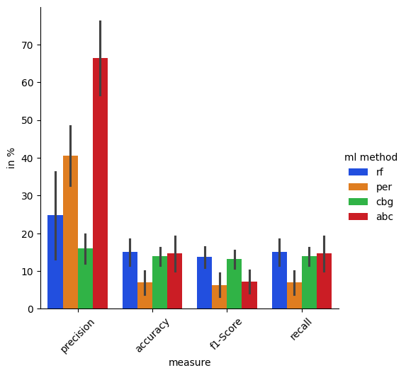

```python
# And the barchart
dalc_adv_deb_perf_metrics_df = pd.DataFrame.from_dict(dalc_adv_deb_perf_metrics)
dalc_adv_deb_init_ml_perf_comp_df = pd.concat([dalc_adv_deb_perf_metrics_df, init_perf_metrics_df], axis=0)
plot_grouped_barchart(data=dalc_adv_deb_init_ml_perf_comp_df, index_col='measure', y_col='in %', stack_name='ml method')
```

```python
# Original Result
display(Markdown('### Dalc Original Results'))
dalc_initial_metrics = calc_bin_label_metrics(dataset=dalc_ds, priv_group=dalc_priv_group, unpriv_group=dalc_unpriv_group, display_results=True)
# Results after adversarial debiasing
display(Markdown('### Dalc - Results after Adversarial Debiasing'))
dalc_adv_deb_bias_metrics = calc_bin_label_metrics(dataset=dalc_adv_deb_predicted, priv_group=dalc_priv_group,
                                                  unpriv_group=dalc_unpriv_group, display_results=True)
```

Dalc Original Results

**Disparate Impact Ratio:** **0.0 %**

**Statistical Parity Difference:** **-1.0**

**Similarity of Data:** **89.0 %**

**Smoothed Empirical Difference Fairness:** **7.04**

Dalc - Results after Adversarial Debiasing

**Disparate Impact Ratio:** **100.0 %**

**Statistical Parity Difference:** **0.0**

**Similarity of Data:** **100.0 %**

**Smoothed Empirical Difference Fairness:** **1.9**

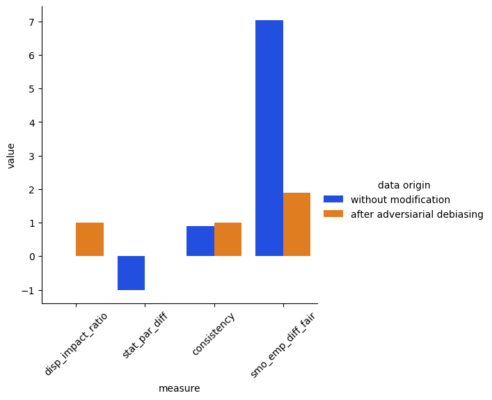

```python
# + plot
dalc_adv_deb_to_conv = {'without modification': dalc_initial_metrics,
               'after adversiarial debiasing': dalc_adv_deb_bias_metrics}

dalc_adv_deb_bias_comp_df = pd.DataFrame.from_dict(dalc_adv_deb_to_conv).reset_index()
dalc_adv_deb_bias_comp_df = dalc_adv_deb_bias_comp_df.rename(columns={'index': 'measure'})
dalc_adv_deb_bias_comp_df = dalc_adv_deb_bias_comp_df.set_index('measure')
dalc_adv_deb_bias_comp_df = dalc_adv_deb_bias_comp_df.stack().to_frame('value').reset_index()
dalc_adv_deb_bias_comp_df = dalc_adv_deb_bias_comp_df.rename(columns={'level_1': 'data origin'})


init_per_plot = sns.catplot(data=dalc_adv_deb_bias_comp_df, x='measure', y='value', hue='data origin', kind='bar', palette='bright')
init_per_plot.set_xticklabels(rotation=45)
plt.show()
```

After applying the adversarial debiasing technique, the results are again quite similar to those obtained using age as a protected attribute. The empirical difference has been reduced quite substantially and the consistency has increased slightly, indicating that the values have been balanced across the different datasets.

## Dalc - Postprocessing

```python
dalc_post_inst = CalibratedEqOddsPostprocessing(unprivileged_groups=dalc_unpriv_group,
                                                privileged_groups=dalc_priv_group)

dalc_post_predicted = dalc_post_inst.fit_predict(dataset_pred=dalc_adv_deb_predicted, dataset_true=dalc_ds_test)
```

```python
# Dalc - Original Result
display(Markdown('### Original Results'))
dalc_initial_bias_metrics = calc_bin_label_metrics(dataset=dalc_ds, priv_group=dalc_priv_group,
                                                   unpriv_group=dalc_unpriv_group, display_results=True)
# Results after postprocessing
display(Markdown('### Results after calibrated equalized odds'))
dalc_post_bias_metrics = calc_bin_label_metrics(dataset=dalc_post_predicted, priv_group=dalc_priv_group,
                                               unpriv_group=dalc_unpriv_group, display_results=True)
```

Original Results

**Disparate Impact Ratio:** **0.0 %**

**Statistical Parity Difference:** **-1.0**

**Similarity of Data:** **89.0 %**

**Smoothed Empirical Difference Fairness:** **7.04**

Results after calibrated equalized odds

**Disparate Impact Ratio:** **100.0 %**

**Statistical Parity Difference:** **0.0**

**Similarity of Data:** **100.0 %**

**Smoothed Empirical Difference Fairness:** **1.9**

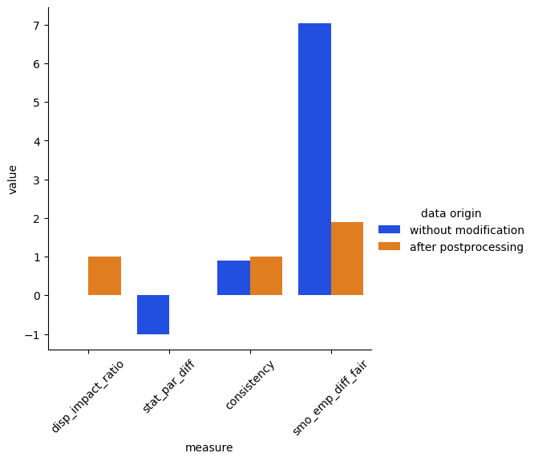

```python
# + plot
dalc_post_to_conv = {'without modification': dalc_initial_bias_metrics,
               'after postprocessing': dalc_post_bias_metrics}

dalc_post_comp_df = pd.DataFrame.from_dict(dalc_post_to_conv).reset_index()
dalc_post_comp_df = dalc_post_comp_df.rename(columns={'index': 'measure'})
dalc_post_comp_df = dalc_post_comp_df.set_index('measure')
dalc_post_comp_df = dalc_post_comp_df.stack().to_frame('value').reset_index()
dalc_post_comp_df = dalc_post_comp_df.rename(columns={'level_1': 'data origin'})

init_per_plot = sns.catplot(data=dalc_post_comp_df, x='measure', y='value', hue='data origin', kind='bar', palette='bright')
init_per_plot.set_xticklabels(rotation=45)
plt.show()
```

Again similarly to the results from age, postprocessing had no impact on the prediction results.

## Summary - Dalc as Protected Attribte

Mirroring the age section of the notebook, the following heatmap summarizes the performance of the ml techniques with dalc, as well as the according bias metrices.

```python
fin_dalc_init_perf_met = init_perf_metrics_df['rf']
fin_dalc_init_perf_met['stage'] = 'without modification'
fin_dalc_rew_metr = dalc_rew_perf_metrics_df['rf']
fin_dalc_rew_metr['stage'] = 'after reweighing'
fin_dalc_adv_deb_metr = dalc_adv_deb_perf_metrics_df['rf']
fin_dalc_adv_deb_metr['stage'] = 'after adversarial debiasing'
dalc_fin_ml_per_df = pd.DataFrame([fin_dalc_init_perf_met, fin_dalc_rew_metr, fin_dalc_adv_deb_metr]).reset_index()
dalc_fin_ml_per_df = dalc_fin_ml_per_df.drop(columns='index').set_index('stage')
dalc_fin_ml_per_df
```

| stage | precision | accuracy | f1-Score | recall |
| --- | --- | --- | --- | --- |
| without modification | 36.32 | 18.46 | 16.43 | 18.46 |
| after reweighing | 28.97 | 14.62 | 12.64 | 14.62 |
| after adversarial debiasing | 13.16 | 11.54 | 11.01 | 11.54 |

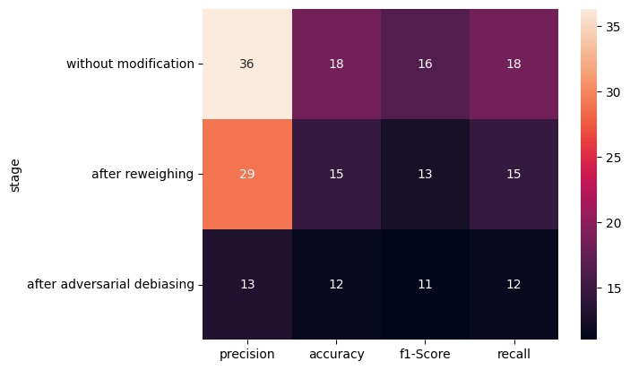

```python
dalc_fin_ml_plot= sns.heatmap(data=dalc_fin_ml_per_df, annot=True)
plt.show()
```

```python
dalc_fin_bias_metrics = {'without modification': initial_bias_metrics,
                        'after reweighing': dalc_rew_bias_metrics,
                        'after adversarial debiasing': dalc_adv_deb_bias_metrics,
                        'after  calculating equalized odds': dalc_post_bias_metrics
                    }

dalc_fin_bias_metrics_df = pd.DataFrame.from_dict(dalc_fin_bias_metrics)
dalc_fin_bias_metrics_df
```

|  | without modification | after reweighing | after adversarial debiasing | after calculating equalized odds |
| --- | --- | --- | --- | --- |
| disp_impact_ratio | 0.00 | 0.00 | 1.0 | 1.0 |
| stat_par_diff | -1.00 | -1.00 | 0.0 | 0.0 |
| consistency | 0.69 | 0.89 | 1.0 | 1.0 |
| smo_emp_diff_fair | 6.84 | 6.87 | 1.9 | 1.9 |

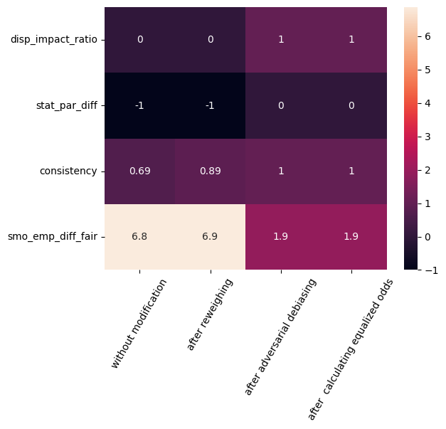

```python
dalc_fin_bias_plot = sns.heatmap(data=dalc_fin_bias_metrics_df, annot=True)
dalc_fin_bias_plot.set_xticklabels(labels=dalc_fin_bias_metrics_df[: 0], rotation=60)
plt.show()
```

## Comparison - Age and Dalc

As final section of this notebook, a quick summary and concluding remarks are provided.

```python
# Prepare the data from Dalc
dalc_ml_perf_comp = dalc_fin_ml_per_df.reset_index()
dalc_ml_perf_comp['prot_attr'] = 'Dalc'

# Perpare the age data
age_ml_perf_comp = age_fin_ml_per_df.reset_index()
age_ml_perf_comp['prot_attr'] = 'age'
age_ml_perf_comp

ml_per_comp = pd.concat([age_ml_perf_comp, dalc_ml_perf_comp], axis=0).reset_index().drop(columns='index')
ml_per_comp = ml_per_comp.sort_values(by='stage')
ml_per_comp
```

|  | stage | precision | accuracy | f1-Score | recall | prot_attr |
| --- | --- | --- | --- | --- | --- | --- |
| 2 | after adversarial debiasing | 13.20 | 11.54 | 10.83 | 11.54 | age |
| 5 | after adversarial debiasing | 13.16 | 11.54 | 11.01 | 11.54 | Dalc |
| 1 | after reweighing | 16.89 | 13.85 | 12.67 | 13.85 | age |
| 4 | after reweighing | 28.97 | 14.62 | 12.64 | 14.62 | Dalc |
| 0 | without modification | 36.32 | 18.46 | 16.43 | 18.46 | age |
| 3 | without modification | 36.32 | 18.46 | 16.43 | 18.46 | Dalc |

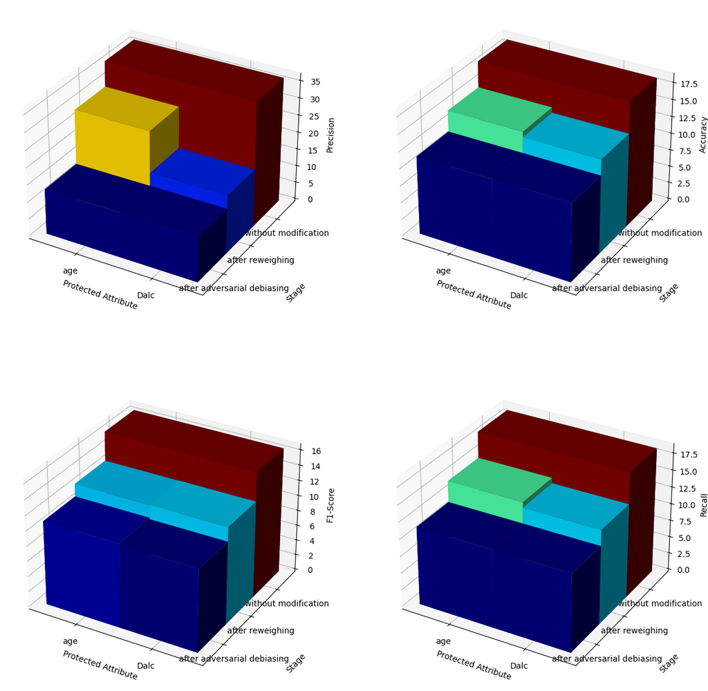

```python
# And now for the plots
plot_cat_3d_barplot(df=ml_per_comp, x_axis_col='prot_attr', y_axis_col='stage', z_axis_cols=['precision', 'accuracy', 'f1-Score', 'recall'],
                    x_label='Protected Attribute', y_label='Stage', z_labels=['Precision', 'Accuracy', 'F1-Score', 'Recall'])
```

### Results - Ml Performance after Bias Mitigation Techniques

As can be seen, the bias reduction techniques had some impact on the overall performance of the Random Forest method used. Although the overall performance can be considered suboptimal, the comparison still provides some insights.

As a last point, we compare the actual bias metrics for the student dataset

```python
# Similar to the performance of the ml module, prepare the data for the 3d-barplot
dalc_bias_metr_comp = dalc_fin_bias_metrics_df.reset_index()
dalc_bias_metr_comp['prot_attr'] = 'Dalc'

age_bias_metr_comp = age_fin_bias_metrics_df.reset_index()
age_bias_metr_comp['prot_attr'] = 'age'

bias_per_comp = pd.concat([age_bias_metr_comp, dalc_bias_metr_comp], axis=0)
bias_per_comp = bias_per_comp.rename(columns={'index': 'stage'}).reset_index().drop(columns='index')
bias_per_comp = bias_per_comp.sort_values(by='stage', ascending=True)
bias_per_comp
```

|  | stage | without modification | after reweighing | after adversarial debiasing | after calculating equalized odds | prot_attr |
| --- | --- | --- | --- | --- | --- | --- |
| 2 | consistency | 0.69 | 0.69 | 1.00 | 1.00 | age |
| 6 | consistency | 0.69 | 0.89 | 1.00 | 1.00 | Dalc |
| 0 | disp_impact_ratio | 0.00 | 0.00 | 1.00 | 1.00 | age |
| 4 | disp_impact_ratio | 0.00 | 0.00 | 1.00 | 1.00 | Dalc |
| 3 | smo_emp_diff_fair | 6.84 | 6.51 | 0.64 | 0.64 | age |
| 7 | smo_emp_diff_fair | 6.84 | 6.87 | 1.90 | 1.90 | Dalc |
| 1 | stat_par_diff | -1.00 | -1.00 | 0.00 | 0.00 | age |
| 5 | stat_par_diff | -1.00 | -1.00 | 0.00 | 0.00 | Dalc |

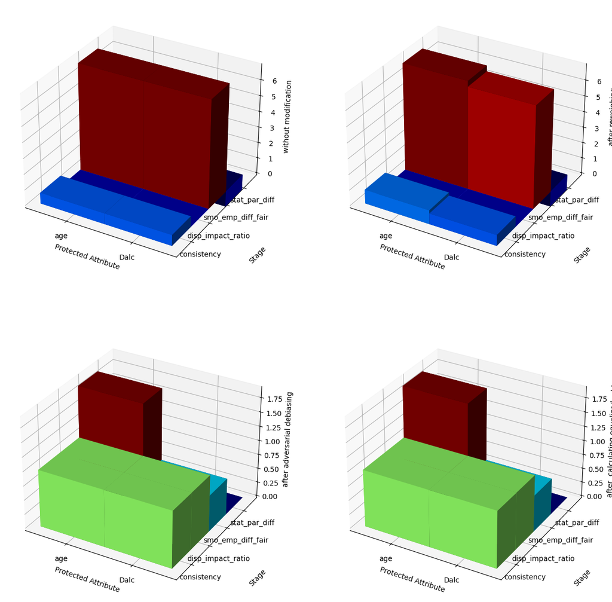

```python
# Finally, plot the barplots
plot_cat_3d_barplot(df=bias_per_comp,
                    x_axis_col='prot_attr',
                    y_axis_col='stage',
                    z_axis_cols=['without modification', 'after reweighing', 'after adversarial debiasing', 'after  calculating equalized odds'],
                    x_label='Protected Attribute',
                    y_label='Stage',
                    z_labels=['without modification', 'after reweighing', 'after adversarial debiasing', 'after  calculating equalized odds'])
```

Unfortunately, sorting had no effect on changing the visibility of the columns. The results as well as the derived final remarks were interpreted from the data frame above.

#### Final Remarks

Overall, the results were quite similar regardless of the protected attribute. As the adaptation of the data progressed (as shown by the consistency and smoothed empirical difference), the statistical parity difference was effectively eliminated, while the disparate impact ratio was maximised. This result suggests that either there is a fundamental error in the application of the methods (which is likely, as indicated at multiple points in the notebook. Moreover, the smoothed empirical difference is theoretically supposed to be a value between 0 and 1). Another possibility is that the techniques work 'too well', leading to an effect similar to overfitting in machine learning. However, this assumption would have to be tested further with other datasets producing more reliable results.

## References

[1] Cortez,Paulo. (2014). Student Performance. UCI Machine Learning Repository. https://doi.org/10.24432/C5TG7T.

[2] Bellamy, R. K., et al (2018).(2019). AI Fairness 360: An extensible toolkit for detecting and mitigating algorithmic bias. IBM Journal of Research and Development, 63(4/5), 4-1.

[3] IBM (2023). Disparate impact in Watson OpenScale fairness metrics | IBM Cloud Pak for Data as a Service. Available at: https://dataplatform.cloud.ibm.com/docs/content/wsj/model/wos-disparate-impact.html?context=data

[4] IBM (n.d.). Statistical parity difference | IBM Cloud Pak for Data as a Service. Available at: https://dataplatform.cloud.ibm.com/docs/content/wsj/model/wos-stat-parity-diff.html?context=cpdaas

[5] IBM (2024). Smoothed empirical differential | IBM Cloud Pak for Data as a Service. Available at: https://dataplatform.cloud.ibm.com/docs/content/wsj/model/wos-smooth-empirical-diff.html?context=cpdaas

[6] Scikit-learn (2018). sklearn.ensemble.RandomForestClassifier — scikit-learn 0.20.3 documentation. Scikit-learn.org. Available at: https://scikit-learn.org/stable/modules/generated/sklearn.ensemble.RandomForestClassifier.html.

[7] scikit-learn (2024). sklearn.linear_model.Perceptron. Available at: https://scikit-learn.org/stable/modules/generated/sklearn.linear_model.Perceptron.html.

[8] Scikit-learn (2009). sklearn.ensemble.GradientBoostingClassifier — scikit-learn 0.20.3 documentation. Available at: https://scikit-learn.org/stable/modules/generated/sklearn.ensemble.GradientBoostingClassifier.html.

[9] scikit-learn (2024). sklearn.ensemble.AdaBoostClassifier — scikit-learn 0.22.1 documentation. Available at: https://scikit-learn.org/stable/modules/generated/sklearn.ensemble.AdaBoostClassifier.html.

[10] Kamiran, F., & Calders, T. (2012). Data preprocessing techniques for classification without discrimination. Knowledge and information systems, 33(1), 1-33.

[11] Zhang, B. H., Lemoine, B., & Mitchell, M. (2018, December). Mitigating unwanted biases with adversarial learning. In Proceedings of the 2018 AAAI/ACM Conference on AI, Ethics, and Society (pp. 335-340).

[12] Pleiss, G., Raghavan, M., Wu, F., Kleinberg, J., & Weinberger, K. Q. (2017). On fairness and calibration. Advances in neural information processing systems, 30.